# Etsy Homework

Charles Mohan

February 4, 2016

# Data Munging

First lets load some libraries and data. I saved the data to my GitHub account so it can be called it from anywhere.

```r
# Libraries
library(dplyr)
library(ggplot2)
library(lubridate)
library(tidyr)
library(scales)
library(broom)
library(pander)

# Data load
product_raw <- read.csv("https://raw.githubusercontent.com/cam333/blog_posts/master/HW_data/product.csv")

product_class_raw <- read.csv("https://raw.githubusercontent.com/cam333/blog_posts/master/HW_data/product_class.csv")

promotion_raw <- read.csv("https://raw.githubusercontent.com/cam333/blog_posts/master/HW_data/promotion.csv")

transactions_raw <- read.csv("https://raw.githubusercontent.com/cam333/blog_posts/master/HW_data/transactions.csv")
```

Next, lets put all the data into one data frame. The `product_class`, `product_raw`, and `transactions_raw` were joined using the `product_class_id` and the `product_id`. The promotion data needed more work to process. The main problem was that `media_type` could be more than one. There is no problem when the promotion had only one media type, but if the promotion used say *radio* and *TV*, the data spilled over on to the next line. This needed to be cleaned up before it could be merged.

```r
class_prod_transactions <- left_join(product_class_raw,product_raw, by = "product_class_id") %>%
            left_join(transactions_raw,., by = "product_id")%>%
            mutate(product_department = gsub("'","",product_department),
                   product_category = gsub("'","",product_category),
                   product_subcategory = gsub("'","",product_subcategory),
                   product_family = gsub("'","",product_family),
                   quarter = gsub("'","",quarter),
                   year = gsub("'","",the_year),
                   month = gsub("'","",month_of_year),
                   brand_name = gsub("'","",brand_name),
                   month_of_year = gsub("'","",month_of_year),
                   date = ymd(paste(year,month,"15",sep ="-")),
                   promotion_id = as.factor(promotion_id)
                   )

all_letters <- paste(paste(letters,collapse="|"),paste(LETTERS,collapse="|"),sep="|")

promotion_data <- data.frame(promotion_raw,stringsAsFactors = FALSE) %>%
  mutate(media_type = gsub("'","",media_type),
         promotion_id = gsub("'","",promotion_id),
         start_date = gsub("'","",start_date),
         end_date = gsub("'","",end_date),
         cost = gsub("'","",cost),
         promotion_name = gsub("'","",promotion_name),
         promotion_district_id = gsub("'","",promotion_district_id),
         # I looked inside the cost variable to see if there were any letters, if so I knew it was actually a media type
         all_types = ifelse(grepl(all_letters,as.character(cost)) == FALSE, media_type,paste(media_type,cost,sep=",")),
         # Then I looked to see where the lead of all_types was empty which told me to look at the promotion_id as the first new date var
         new_date_1 = ifelse(lead(all_types) == "",lead(promotion_id),"false"),
         # Then I needed to know if the data was shifted by more than one, checking the promotion_district_id did this.
         new_date_2 = ifelse(lead(promotion_district_id) != "" & lead(all_types) == "", lead(promotion_district_id), "false"),
         # next step was to create a complete data field (at the end I'll fix a few errors here)
         real_start_date = ifelse(new_date_1 == "false" & new_date_2 == 'false',start_date,new_date_1),
         real_end_date =   ifelse(new_date_1 != "false" & new_date_2 != 'false',new_date_2,end_date),
         # then I had to clean up the cost data.
         real_cost =  ifelse(lead(promotion_id)!= "" & lead(promotion_district_id) != "" & lead(all_types) == "", end_date,
                      ifelse(lead(promotion_id)!= "" & lead(promotion_district_id) == "", start_date, cost))) %>%
  filter(real_start_date != "" & real_start_date != "NULL" ) %>%
  mutate(all_types = gsub("'","",all_types)) %>%
  select(-new_date_1,-new_date_2,-start_date,-end_date,-cost) %>%
  mutate(real_date1 = ymd_hms(real_start_date),
         real_date2 = ymd_hms(real_end_date),
         real_cost = as.numeric(real_cost)) %>%
  rowwise()%>%
  #this is a final check that the start and end dates are in the correct order.
  mutate(real_start_date = min(real_date1,real_date2),
         real_end_date = max(real_date1,real_date2)) %>%
  #this might be useful at some point.
  mutate(promotion_interval = interval(real_start_date,real_end_date),
         check = real_start_date - real_end_date) %>%
  select(-real_date1,-real_date2)

# final join
all_data <-left_join(class_prod_transactions,promotion_data, by = "promotion_id")
```

# Summary Analysis

## Some simple stats:

- Range of data-set: 1997-01-15 to 1997-12-15
- Number of stores: 5589
- Total sales: 112,111,664
- Products:
  - Number of departments: 22
  - Number of categories: 45
  - Number of subcategories: 102
- Number of brands: 111

## Unit Sales by Product Department

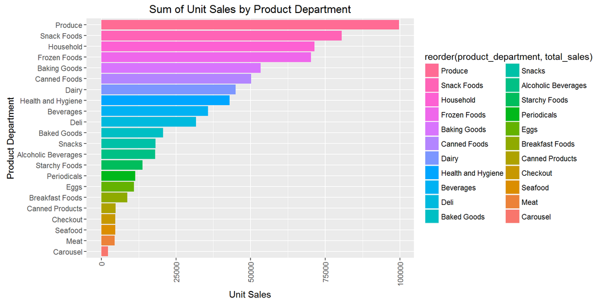

```r
department_data <- all_data  %>%
  group_by(product_department) %>%
  summarize(total_sales = sum(as.numeric(unit_sales), na.rm = TRUE)) %>%
  na.omit()

ggplot(department_data, aes(x = reorder(product_department,total_sales), y = total_sales)) +
  geom_bar(stat = 'identity',aes(fill = reorder(product_department,total_sales))) +
  theme(axis.text.x=element_text(angle=90,hjust=1,vjust=0.5)) +
  coord_flip()+
  guides(fill = guide_legend(reverse = TRUE)) +
  xlab("Product Department") +
  ylab("Unit Sales") +
  ggtitle("Sum of Unit Sales by Product Department")
```

## Unit Sales by Product Category

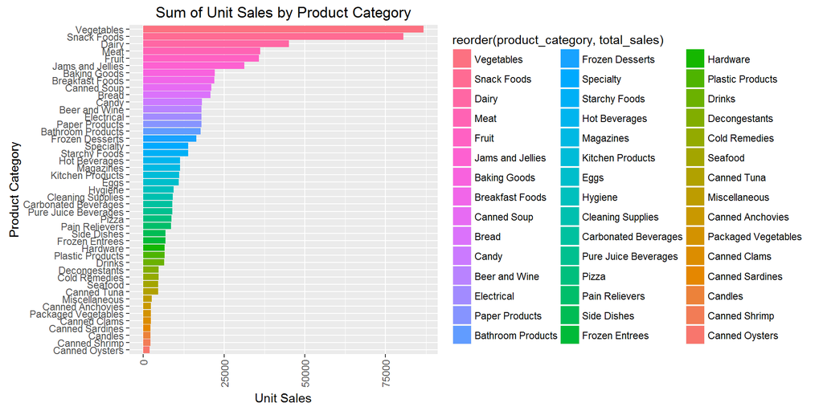

```r
category_data <- all_data  %>%
  group_by(product_category) %>%
  summarize(total_sales = sum(as.numeric(unit_sales), na.rm = TRUE)) %>%
  na.omit()

ggplot(category_data, aes(x = reorder(product_category,total_sales), y = total_sales)) +
  geom_bar(stat = 'identity',aes(fill = reorder(product_category,total_sales))) +
  theme(axis.text.x=element_text(angle=90,hjust=1,vjust=0.5)) +
  coord_flip()+
  guides(fill = guide_legend(reverse = TRUE)) +
  xlab("Product Category") +
  ylab("Unit Sales") +
  ggtitle("Sum of Unit Sales by Product Category")
```

## Unit Sales by Product Brand

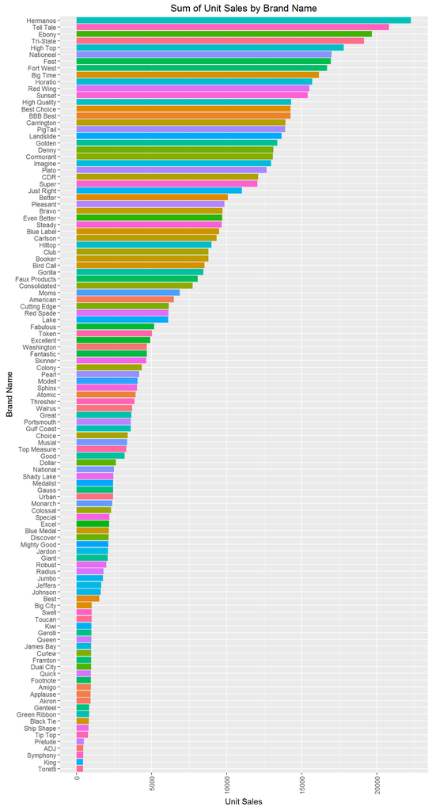

```r
brand_data <- all_data  %>%
  group_by(brand_name) %>%
  summarize(total_sales = sum(as.numeric(unit_sales), na.rm = TRUE)) %>%
  na.omit()

ggplot(brand_data, aes(x = reorder(brand_name,total_sales), y = total_sales)) +
  geom_bar(stat = 'identity',aes(fill = brand_name)) +
  theme(axis.text.x=element_text(angle=90,hjust=1,vjust=0.5),legend.position = "none") +
  coord_flip()+
  xlab("Brand Name") +
  ylab("Unit Sales") +
  ggtitle("Sum of Unit Sales by Brand Name")
```

## promotions

#### All promotions

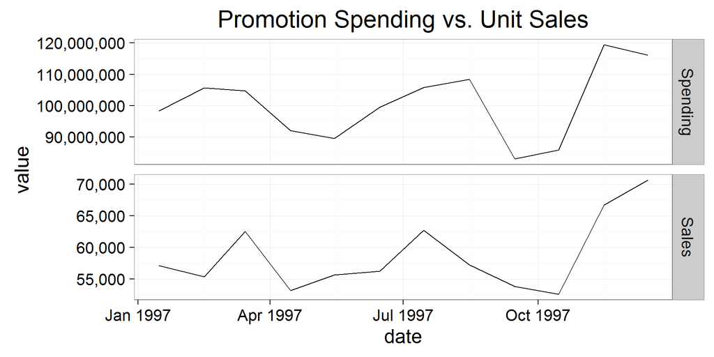

```r
options(scipen=999)
promotion_spending <- all_data %>%
  group_by(date) %>%
  summarize(Spending = sum(real_cost, na.rm = TRUE), Sales = sum(as.numeric(unit_sales), na.rm = TRUE)) %>%
  na.omit() %>%
  gather(variable, value,-date)

ggplot(promotion_spending, aes(x=date, y=value)) +
  geom_line() +
  scale_y_continuous( labels = comma)+
  ggtitle("Promotion Spending vs. Unit Sales") +
  facet_grid(variable~., scales = "free_y") +
  theme_bw(base_size = 20)
```

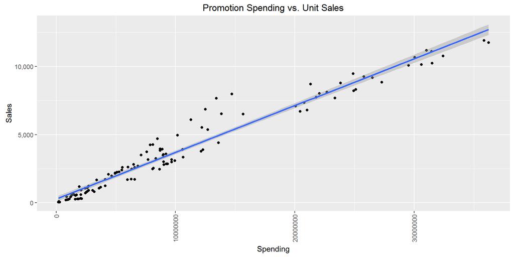

```r
options(scipen=999)
promotion_spending_type <- all_data %>%
  group_by(date,all_types) %>%
   summarize(Spending = sum(real_cost, na.rm = TRUE), Sales = sum(as.numeric(unit_sales), na.rm = TRUE)) %>%
   na.omit()

ggplot(promotion_spending_type, aes(x=Spending, y=Sales)) +
  geom_point() +
  stat_smooth(method = "lm") +
  scale_y_continuous( labels = comma) +
  theme(axis.text.x=element_text(angle=90,hjust=1,vjust=0.5),legend.position = "none")  +
    ggtitle("Promotion Spending vs. Unit Sales")
```

There is definitely a relationship between promotion spending and sales. How does this relationship differ by media type?

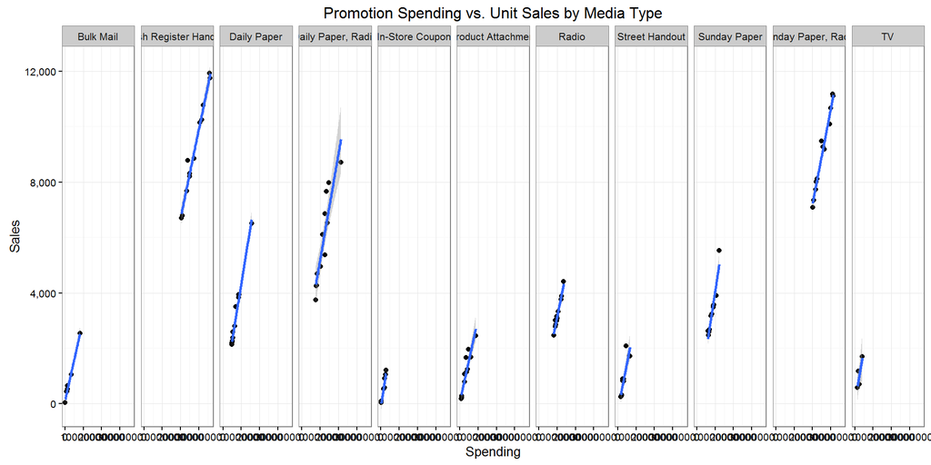

```r
# options(scipen=999)
# promotion_spending_type <- all_data %>%
#   group_by(date,all_types) %>%
#    summarize(Spending = sum(real_cost, na.rm = TRUE), Sales = sum(as.numeric(unit_sales), na.rm = TRUE)) %>%
#    na.omit()

ggplot(promotion_spending_type, aes(x=Spending, y=Sales)) +
  geom_point() +
  stat_smooth(method = "lm") +
  scale_y_continuous( labels = comma) +
  theme(axis.text.x=element_text(angle=90,hjust=1,vjust=0.5),legend.position = "none") +
  ggtitle("Promotion Spending vs. Unit Sales by Media Type") +
  facet_grid(.~all_types, scales = "free_y") +
  theme_bw(base_size = 10)
```

Looks like all of the media types have the intended result of increasing sales as as you spend more.

What does the response look like by department?

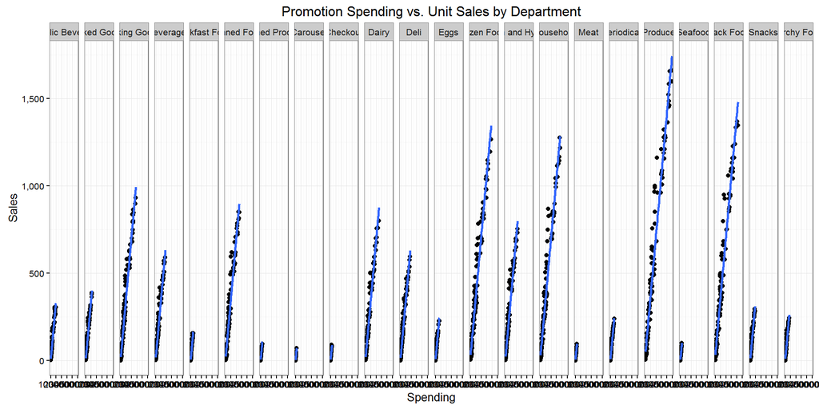

```r
promotion_spending_dept <- all_data %>%
  group_by(date,product_department,all_types) %>%
   summarize(Spending = sum(real_cost, na.rm = TRUE),
             Sales = sum(as.numeric(unit_sales), na.rm = TRUE)) %>%
   na.omit()

ggplot(promotion_spending_dept, aes(x=Spending, y=Sales)) +
  geom_point() +
  stat_smooth(method = "lm",se = FALSE) +
  scale_y_continuous( labels = comma) +
  theme(axis.text.x=element_text(angle=90,hjust=1,vjust=0.5),legend.position = "none") +
  ggtitle("Promotion Spending vs. Unit Sales by Department") +
  facet_grid(.~product_department, scales = "free_y") +
  theme_bw(base_size = 10)
```

Again, it seems that all the departments are giving a strong response.

Lets look at all combinations of the top five departments (with respect to unit sales) by the top five media types (with respect to total spending).

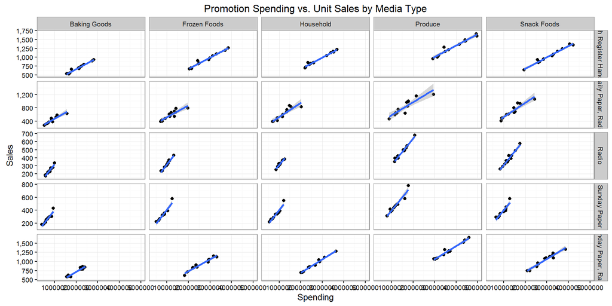

```r
promotion_spending_all <- all_data %>%
  group_by(product_department) %>%
   summarize(Spending = sum(real_cost, na.rm = TRUE),
             Sales = sum(as.numeric(unit_sales), na.rm = TRUE)) %>%
   na.omit()%>% arrange(desc(Spending))

promotion_spending_type_sum <- all_data %>%
  group_by(all_types) %>%
   summarize(Spending = sum(real_cost, na.rm = TRUE),
             Sales = sum(as.numeric(unit_sales), na.rm = TRUE)) %>%
   na.omit()  %>% arrange(desc(Spending))


promotion_spending_dept_f <- all_data %>%
  filter(product_department %in% head(promotion_spending_all$product_department,5) &
         all_types %in% head(promotion_spending_type_sum$all_types,5)) %>%
  group_by(date,product_department,all_types) %>%
   summarize(Spending = sum(real_cost, na.rm = TRUE),
             Sales = sum(as.numeric(unit_sales), na.rm = TRUE)) %>%
   na.omit()



ggplot(promotion_spending_dept_f, aes(x=Spending, y=Sales)) +
  geom_point() +
  stat_smooth(method = "lm") +
  scale_y_continuous( labels = comma) +
  theme(axis.text.x=element_text(angle=90,hjust=1,vjust=0.5),legend.position = "none") +
  ggtitle("Promotion Spending vs. Unit Sales by Media Type") +
  facet_grid(all_types~product_department, scales = "free_y") +
  theme_bw(base_size = 10)
```

# Recomendation

All combinations, which one should be picked?

```r
promotion_spending_dept_full <- all_data %>%
  group_by(date,product_department,all_types) %>%
   summarize(Spending = sum(real_cost, na.rm = TRUE),
             Sales = sum(as.numeric(unit_sales), na.rm = TRUE)) %>%
  na.omit()

promotion_spending_count <-promotion_spending_dept_full %>%
         group_by(product_department,all_types) %>%
         summarize(count =n()) %>%
         filter(count >10)

ten_months_or_more <- left_join(promotion_spending_count,promotion_spending_dept_full)
```

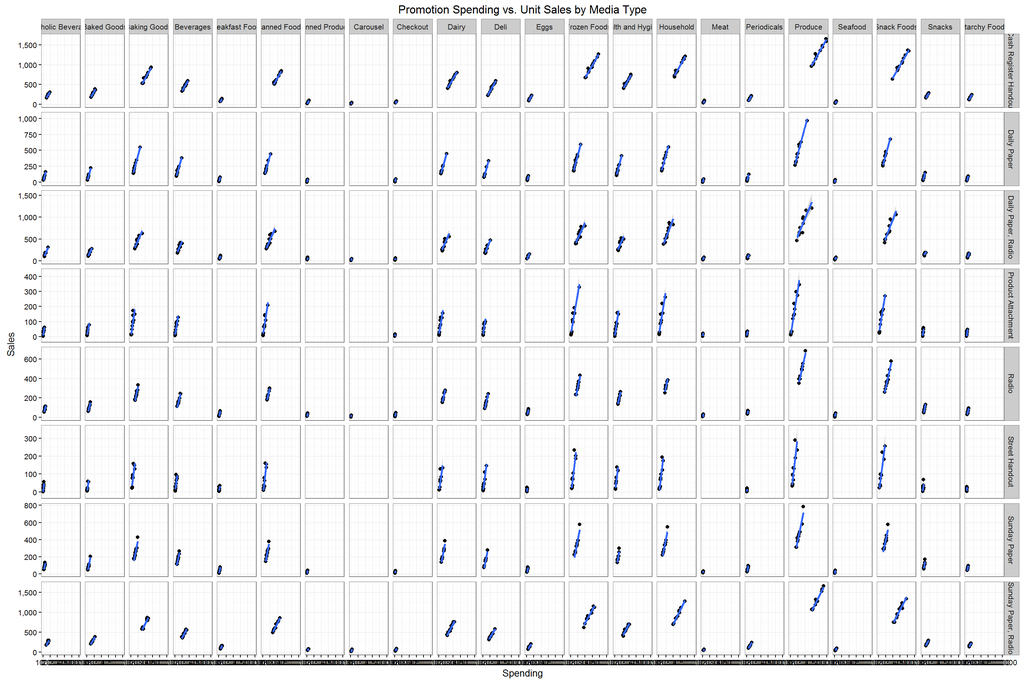

```r
ggplot(ten_months_or_more, aes(x=Spending, y=Sales)) +
  geom_point() +
  stat_smooth(method = "lm") +
  scale_y_continuous(labels = comma) +
  theme(axis.text.x=element_text(angle=90,hjust=1,vjust=0.5),legend.position = "none") +
  ggtitle("Promotion Spending vs. Unit Sales by Media Type") +
  facet_grid(all_types~product_department, scales = "free_y") +
  theme_bw(base_size = 10)
```

If you sort all the combinations (that have > 10 data points) of promotion type (can include dual types) and product department by the slope, you can see which combination might be the most effective.

```r
est <- ten_months_or_more %>%
  group_by(product_department,all_types) %>%
  do(tidy(lm(Sales ~ Spending, data = .))) %>%
  filter(term == "Spending") %>% ungroup() %>%
  arrange(desc(estimate)) %>%
  select(product_department,all_types,term, estimate)


pandoc.table(head(est,10))
```

```
##
## -------------------------------------------------------------
##  product_department      all_types        term     estimate
## -------------------- ------------------ -------- ------------
##   Canned Products    Daily Paper, Radio Spending 0.0005904410
##
##  Health and Hygiene     Sunday Paper    Spending 0.0004839752
##
##         Meat         Daily Paper, Radio Spending 0.0004612810
##
##    Starchy Foods       Street Handout   Spending 0.0004554867
##
##        Snacks           Sunday Paper    Spending 0.0004542169
##
##     Canned Foods        Sunday Paper    Spending 0.0004442975
##
##        Dairy            Sunday Paper    Spending 0.0004420752
##
##       Checkout       Daily Paper, Radio Spending 0.0004403638
##
##       Carousel       Daily Paper, Radio Spending 0.0004387950
##
##       Seafood           Daily Paper     Spending 0.0004371117
## -------------------------------------------------------------
```

The above table would be the top ten most effect promotions to run.